# Beaver2 DataSet Analysis

1. We want to compute the average temperature when beaver is not active, and when it is active. (activ=0: no activity, activ=1: activity)

```r
mean(nonActiveBeaver$temp)
```

```
[1] 37.09684
```

```r
mean(activeBeaver$temp)
```

```
[1] 37.90306
```

2. Now we want to test for a difference in body temperature as a function of activity. Which test do we use? Is there a difference in temperature as a function of activity?

We need to understand which is the correct test to use, and to do it We have to check for normality. The sample here has a size of 100, so let’s say it’s not too small. Then I have to check by visual inspection and by formal testing if the distribution follows a normal curve.

To check by visual inspection, We need to use R function “hist()”, and to do a formal test We need to use the Shapiro test.

Visually, we can see that the temperature of an active beaver does follow a normal curve, and this is the same for a inactive beaver:

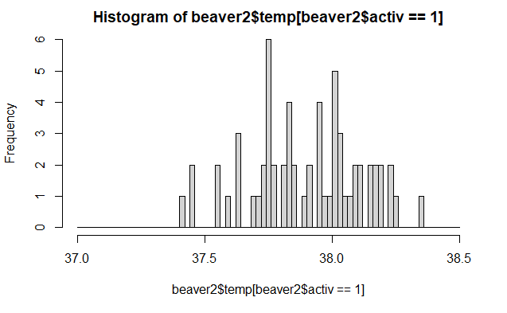

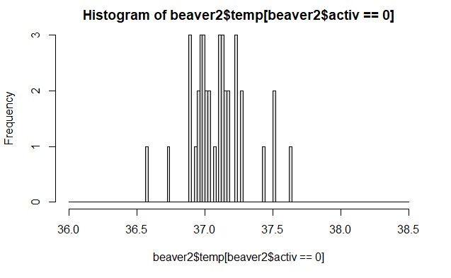

This is confirmed by the Shapiro test. Let’s use the function “tapply”:

```r
tapply(beaver2$temp, beaver2$activ, shapiro.test)
```

```
$`0`

    Shapiro-Wilk normality test

data:  X[[i]]
W = 0.95427, p-value = 0.1231


$`1`

    Shapiro-Wilk normality test

data:  X[[i]]
W = 0.98326, p-value = 0.5583
```

Both pvalues are bigger than 0.05, so the distributions fit into a normal curve.

Therefore, I can use a normal two sample t-test. There is a t = -18.548 and a pvalue of approximately 0. Both numbers show that there is a significant difference between the temperatures as a function of activity.

```r
t.test(beaver2$temp ~ beaver2$activ)
```

```
    Welch Two Sample t-test

data:  beaver2$temp by beaver2$activ
t = -18.548, df = 80.852, p-value < 2.2e-16
alternative hypothesis: true difference in means between group 0 and group 1 is not equal to 0
95 percent confidence interval:
 -0.8927106 -0.7197342
sample estimates:
mean in group 0 mean in group 1
       37.09684        37.90306
```